# FinalProject - R Wizardry

Rowan R

11/04/2022

## Introduction

Without interactions, ecology, and likely life on earth would not exist. Interactions underpin the functioning of communities through transfer of energy, often in the form of nutrients (Jordano, 2016). A well-known example of interacting organisms is the food web, where predator-prey relationships form an interwoven network of several “levels” of organism, from primary producers, to herbivores, to predators. These relationships can be complex, but this complexity can provide stability to the network, as a result of many organisms tending to rely on several others. This reliance on several organisms means that the loss of an organism by chance does not immediately lead to the loss of all the organisms that relied on the extirpated organism (Montoya et al. 2006). To attempt to describe and understand the groups of interactions that occur in communities, it is necessary to build and analyze interaction networks (Delmas et al. 2019). Plant-pollinator networks have received attention in recent years as they may be able to inform conservation and restoration by identifying key plant species to provide for pollinators. The effectiveness of restoration efforts in restoring networks and ecosystem function has also been investigated (Forup et al. 2008, Kaiser-Bunbury, 2017). Such networks that contain only two levels (i.e., plants and pollinators) are called bipartite networks, which will be the focus of this tutorial.

A variety of quantitative network metrics can be generated for use in quantitative analyses using the existing well known R package “bipartite” (Dormann et al. 2008, and see Dormann, 2021 for a vignette). These are well documented and useful for scientific papers, but what about visualization? It is important to represent these complex systems visually in a way that retains the complexity but avoids being overwhelmingly dense to comprehend. This is particularly important when communicating science to non-experts, such as funders or the public. Finally, R packages have recently become available that can produce interactive figures, which provide an element of exploration and discovery not possible with static figures. I will provide methods for manipulating data into the formats required to produce network visualizations, then provide a practical guide to using a package called bipartiteD3 to create interactive html networks.

Since the quantitative analysis of bipartite networks is done in R, it is sensible to also do the visualizations in R using the same data. As described in Terry (2021), D3 graphics use javascript to produce html figures in R, without ecologists needing to learn an entirely new programming language. My tutorial will show how to solve the common problems that occur when trying to visualise real networks using bipartiteD3. I will also be demonstrating the use of a group of R packages called the tidyverse, which will be used to streamline data processing and allow the generation of many figures more quickly than base R. (Wickham et al. 2019). Tidyverse functions can be used in many other scenarios, so they are worth demonstrating here. Together, these two packages provide an approachable, relatively quick method for ecologists to process and visualize interaction data that would have been prohibitively time or computing intensive before the creation of these tools.

## Tutorial

To begin the tutorial, we need to set up our working directory to make data import easy. It is helpful to create a project directory using Rstudio, by selecting options in the top left corner. First select file, then new project, new project again, then select a convenient location on your computer. Once a project folder has been created, put this R markdown file into it along with the data file, open the project, then open this R markdown file using open file. Then check the working directory is set to the project directory you just chose using the command below. If not, it can be selected using session -> set working directory -> To project directory. A project is not necessary but makes finding saved files easier.

```r
getwd() #check your working directory is set to the project directory, if not specify below or select session, set working directory, to project directory
setwd("yourdirhere")
```

Next, install the packages required for data manipulation (tidyverse) and for standard network analysis (bipartite). We will install the required bipartiteD3 packages later. Dependencies ensures packages required by the installed package are also installed.

```r
install.packages("tidyverse") #install packages required
install.packages("bipartite", dependencies = TRUE)
#packages only need to be installed once
```

After installing, packages need to be loaded using library().

```r
#First clear the workspace
rm(list = ls(all = T))

#after installing, load packages using library to make them available for use
library(tidyverse)
library(bipartite)
library(bipartiteD3)
```

#### Data Import & Tidyverse introduction

The tidyverse is a group of packages that act in similar ways. Many base R functions have a tidyverse counterpart, and there are many functions to complete tasks that would require several steps in base R. When importing data, the tidyverse uses tibbles instead of data frames. Also, the tidyverse (dplyr) read functions do not auto convert data types (i.e. strings as factors), and also don’t require header=TRUE, they assume the first row is column names.

```r
rawdata<- read_csv("2021CamasDataFinalProj.csv")
#read in file, using a read function (read_csv) matching the file type(csv)
#another tibble quirk: running the tibble name prints only the first 10 rows. In an R markdown, we only get the variables that fit on one page, the rest are listed as seen below.

#to see all the variables in one place, either run rawdata yourself in Rstudio, use str(rawdata) or view all variables and observations using view(rawdata)

rawdata
```

| Code | Round | date | Start_Day | Start_Month | Start_Year | sex | Genus | species | associated_taxa | Locality | Sample_ID | Specimen_ID | Prefix | Sequence | Country | State | County | Decimal_Latitude | Decimal_Longitude | Elevation_(m) | End_Day | End_Month | End_Year | Collection Method | Associated_taxa_scientific_name | Observer_Collector_Specific | Notes | Order | caste | … |
| --- | --- | --- | --- | --- | --- | --- | --- | --- | --- | --- | --- | --- | --- | --- | --- | --- | --- | --- | --- | --- | --- | --- | --- | --- | --- | --- | --- | --- | --- | --- |
| MAR | 1 | 2021-05-10 | 10 | 5 | 2021 | female | Bombus | vancouverensis | Camassia quamash | Marsden Face | NA | KNPS-obs1 | KNPS- | obs1 | CAN | BC | RDCK | 49.503 | -117.371 | 610 | 10 | May | 2021 | Observed | NA | R.Rampton; T.Ernst | NA | NA | F | … |
| MAR | 1 | 2021-05-10 | 10 | 5 | 2021 | female | Bombus | vancouverensis | Camassia quamash | Marsden Face | NA | KNPS-obs2 | KNPS- | obs2 | CAN | BC | RDCK | 49.503 | -117.371 | 610 | 10 | May | 2021 | Observed | NA | R.Rampton; T.Ernst | NA | NA | F | … |
| MAR | 1 | 2021-05-10 | 10 | 5 | 2021 | female | Bombus | vancouverensis | Camassia quamash | Marsden Face | NA | KNPS-obs3 | KNPS- | obs3 | CAN | BC | RDCK | 49.503 | -117.371 | 610 | 10 | May | 2021 | Observed | NA | R.Rampton; T.Ernst | NA | NA | F | … |
| MAR | 1 | 2021-05-10 | 10 | 5 | 2021 | female | Bombus | vancouverensis | Camassia quamash | Marsden Face | NA | KNPS-obs4 | KNPS- | obs4 | CAN | BC | RDCK | 49.503 | -117.371 | 610 | 10 | May | 2021 | Observed | NA | R.Rampton; T.Ernst | NA | NA | F | … |
| SEC | 2 | 2021-05-29 | 29 | 5 | 2021 | female | Apis | mellifera | Camassia quamash | Secret Meadow | NA | KNPS-obs5 | KNPS- | obs5 | CAN | BC | RDCK | 49.332 | -117.618 | 520 | 29 | May | 2021 | Observed | NA | R.Rampton; T.Ernst | NA | NA | W | … |
| SEC | 2 | 2021-05-29 | 29 | 5 | 2021 | female | Apis | mellifera | Camassia quamash | Secret Meadow | NA | KNPS-obs6 | KNPS- | obs6 | CAN | BC | RDCK | 49.332 | -117.618 | 520 | 29 | May | 2021 | Observed | NA | R.Rampton; T.Ernst | NA | NA | W | … |
| SEC | 2 | 2021-05-29 | 29 | 5 | 2021 | female | Apis | mellifera | Camassia quamash | Secret Meadow | NA | KNPS-obs7 | KNPS- | obs7 | CAN | BC | RDCK | 49.332 | -117.618 | 520 | 29 | May | 2021 | Observed | NA | R.Rampton; T.Ernst | NA | NA | W | … |
| KPI | 2 | 2021-05-29 | 29 | 5 | 2021 | female | Apis | mellifera | Rosa nutkana | kp'itl'els | NA | KNPS-obs8 | KNPS- | obs8 | CAN | BC | RDCK | 49.317 | -117.650 | 425 | 29 | May | 2021 | Observed | NA | R.Rampton; T.Ernst | NA | NA | W | … |
| GCR | 2 | 2021-06-02 | 2 | 6 | 2021 | female | Bombus | appositus | Delphinium nuttallianum | Goose Creek Road | NA | KNPS-obs9 | KNPS- | obs9 | CAN | BC | RDCK | 49.430 | -117.662 | 1120 | 2 | June | 2021 | Observed | NA | R.Rampton; T.Ernst | NA | NA | Q | … |
| CRV | 3 | 2021-06-08 | 8 | 6 | 2021 | female | Apis | mellifera | Symphoricarpos albus | Crescent Valley | NA | KNPS-obs10 | KNPS- | obs10 | CAN | BC | RDCK | 49.442 | -117.547 | 485 | 8 | June | 2021 | Observed | NA | R.Rampton; T.Ernst | NA | NA | F | … |

[output cut: 1000 more lines]

#### What is this raw data?

This is a data set of pollinators collected on various plants in eight meadows over a field season. Each observation is one record of a pollinator, with associated information like the location of collection, the flower it was collected on, plus the species and genus identity of the pollinator and more.

We can begin with a simple task, providing a list of taxa present, which may be requested by government, funders, or conservation organizations, especially when writing reports.

```r
unique(rawdata$Genus) #get a list of unique pollinator genera
```

```
##  [1] "Bombus"       "Apis"         "Lasioglossum" "Osmia"        NA
##  [6] "Megachile"    "Ceratina"     "Nomada"       "Halictus"     "Andrena"
## [11] "Melecta"      "Macropis"     "Melissodes"   "Anthophora"   "Hylaeus"
## [16] "Agapostemon"  "Hoplitis"     "Eucera"       "Heriades"     "Chelostoma"
## [21] "Sphecodes"    "Dufourea"     "Habropoda"    "Anthidium"    "Panurginus"
## [26] "Colletes"     "Stelis"
```

```r
#Note that for reporting, we would want to remove the NA, but we will do that more elegantly later (then if desired, re run this line of code on the NA removed data). We're not getting a species list right now because species is currently a single column (no latin binomials yet)
```

#### Getting raw data ready for analysis

Incoming data is often not R friendly and tends to need some cleaning up before use in analyses. Luckily in this data each observation is contained in one row, which is the type of data (called tidy data) that tidyverse functions are designed to work with. We can use tidyverse (specifically dplyr) functions to make necessary modifications to the data before working with network functions.

In the tidyverse, multiple operations can be combined into a few lines of code using the pipe operator ( %>% ). The pipe operator can be thought of as ‘then do’, so we can take our data then do (%>%) the next function. The following is an introductory example of a one step process, choosing only the rows that have an identified pollinator, in this case all of the bees. This is done by keeping only rows that do not have a missing value in the Genus column, an NA means that the insect was not identified (in this data set missing rows are insects that were not bees, such as wasps or beetles).

```r
beesonly<- rawdata %>% #assign to a new data frame, using rawdata, then:
  filter(!is.na(Genus))
#keep only rows without a missing value in the Genus column.
```

Real data also tends to have errors. These can be fixed in Excel, but when values occur in multiple locations or more than one mistake needs to be corrected, it makes sense to fix them in R. The tidyverse function mutate can be used to create new variables, or replace existing variables with updated ones. Many functions can be used within mutate, such as recode, which takes as arguments: a column, the value in the column that should be replaced, then the value that is to replace it.

```r
beesonly<- beesonly %>% #reassign the data after:
  mutate(species = recode(species, "Nuda" = "nuda")) %>%
  #replacing a capitalized species name with a lowercase species name, then
  mutate(species = recode(species, "perhirta" = "perihirta"))
  #fixing an "i" that was missed during data entry
```

Now that we have selected our bees and their names are correct, we have another issue. We can see in the data that the bee species names are currently separated into genus and species columns, and bipartite network functions require a single column or row for each organism name (i.e. a latin binomial species name). We can combine a genus and species column into one column which will be done below using the unite function. The arguments are: Name of new column, range of columns to combine (in this case they are next to each other in the data frame so the : means from genus column to species), then what to separate the values by, in this case a single space.

```r
beesonly<- beesonly%>%
  unite("BeeName", Genus:species, sep = " ") #unite two columns into one

beesonly %>% select(BeeName)
```

| BeeName |
| --- |
| Bombus vancouverensis |
| Bombus vancouverensis |
| Bombus vancouverensis |
| Bombus vancouverensis |
| Apis mellifera |
| Apis mellifera |
| Apis mellifera |
| Apis mellifera |
| Bombus appositus |
| Apis mellifera |

[output cut: 837 more lines]

```r
#select keeps the listed columns, so this is printing (but not saving) the BeeName column, and because it is a tibble, it should print only the first 10 rows. We can see the unite worked.
```

Now that we have data that include the variables necessary to make bipartite networks, we can select some variables of interest out of the many that were included. Our required ones include associated taxa (the plants bees were caught on), BeeName (the bee species), then we have things we might want to explore later on like site (aka Code), elevation or sampling round.

```r
beesonly<- beesonly %>% #take data then:
  select(associated_taxa,BeeName,Code,date,Round,`Elevation_(m)`,specimen)
#select columns of interest: plants and bees, site code, date, round of sampling, elevation, whether a specimen was collected or not.
#Note we are overwriting the data with only these variables.
```

#### bipartite

As mentioned above, some functions require different formats, such as matrices. For example, bipartite, the network analysis package requires a matrix with plant names in the first column, then each pollinator species as its own column, with each row the number of interactions between each plant and pollinator combination.

As is, the data is all individual observations, and needs to be converted into the above form, where each plant-pollinator interaction has a count. This can be done using the dplyr functions group_by and summarise. group_by allows functions further down the pipe to act on groups of rows that share values of a certain column instead of simply all rows. Summarise does what it says, it provides a single number average, or counts, or standard deviations of a group of rows. Together group by and summarise can provide summaries of groups, which is what we want: groups for every plant-pollinator interaction, and a count of each group, which represents how many times that interaction occurred. Below we will group_by flowering plant and bee species, then summarise the number of times that combo occurred. This number of occurrences is often described as weighting in network analyses.

```r
beesperflower<- beesonly %>% #get data set then
  group_by(associated_taxa,BeeName) %>%
  #group by flowering plant and bee species, then
  summarise(n = n())
  #summarise the number in each group, newvariablename = function()

beesperflower #examine new tibble, each row is a plant-pollinator interaction with a count n.
```

| associated_taxa | BeeName | n |
| --- | --- | --- |
| Achillea millefolium | Andrena sigmundi | 1 |
| Achillea millefolium | Lasioglossum albipenne | 3 |
| Achillea millefolium | Lasioglossum punctatoventre | 1 |
| Achillea millefolium | Nomada sp. 9 | 1 |
| Achillea millefolium | Sphecodes sp. 3 | 1 |
| Allium cernuum | Bombus rufocinctus | 2 |
| Allium cernuum | Ceratina acantha | 1 |
| Allium cernuum | Ceratina nanula | 1 |
| Allium cernuum | Halictus tripartitus | 1 |
| Allium cernuum | Heriades carinatus | 4 |

[output cut: 376 more lines]

We still aren’t at a matrix yet, we need to have one row for each plant, with each bee species as a column name. We can turn the current ‘tidy’ data into a matrix by using a pivot function. pivot_wider takes data within a column and turns each unique value into its own column, with the values for each new column coming from another specified column. In this and most data destined for network analysis, not every combination will exist. Another way to think of this is that each plant will not necessarily have an interaction with every pollinator. In R, a pivot function will not know this, and by default will fill such non-existing (or non-detected) interactions with NAs, when they should be zeroes. Luckily pivot_wider takes an argument called values_fill to fill unknown values (NAs) with a specified value (0 in this case). bipartite also requires plant names to be row names instead of an actual column, so the last step converts the associated taxa column to row names.

```r
interactmatrix <- beesperflower %>% #get data then do:
  pivot_wider(names_from = BeeName,
  #pivot wider, get column names from species column
    values_from = n, values_fill = 0)  %>%
    #numbers from n column, fill NAs with 0, then
  column_to_rownames(.,var = "associated_taxa")
  #make the first column using the data from above (the . indicates this) into row names
```

Now we can use the standard network package (bipartite) to get some network metrics for the matrix. Note these may take some time to run. The output of species level is a list containing each “level” of the network. The two levels are the two types of organisms being compared, in this case plants and pollinators. The first level in the list is the pollinators, or the columns. The second in the list is the plants, or the rows. Each level contains many metrics that describe each species as it relates to the network (e.g. how many plants a given pollinator species visits). networklevel computes metrics for the entire network. The main goal of including this section is to know how to get data into the required format to get these metrics.

```r
bispp<- specieslevel(interactmatrix) #can get metrics for each of the species
pollmetrics<- bispp[[1]] #gets the pollinator metrics
plantmetrics <- bispp[[2]] #gets the plant metrics

binet <- networklevel(interactmatrix) #whole network matrix
```

Some brief examples of these metrics are as follows. A per species metric is degree, which represents the number of species in the opposite level that the given species interacts with. For example, a plant with a degree of 10 means it interacted with 10 species of pollinators. For the whole network, basic examples of metrics include “number of species LL” and “HL” (lower level and higher level, verify which is which in your data, which can be achieved using the unique command above), as well as an average number of “links per species”, which averages the number of other species each species interacted with (for all species in the network). Many of these metrics are complex and are better described in a statistical or mathematical tutorial (e.g, Dormann, 2021).

Instead of bipartite metrics, we are going to focus on visualization. bipartite itself provides a function to represent networks visually, which is called plotweb. Shown below, it does not provide very pleasant output by default, and the options to adjust it are not immediately intuitive. It also doesn’t appear possible to highlight (selectively colour) certain plant or pollinator species, which is important when working with more complex networks such as the one plotted below.

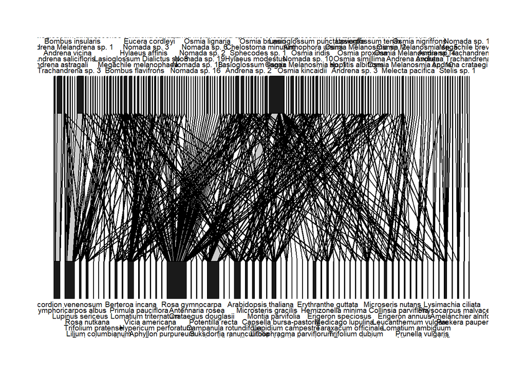

```r
plotweb(interactmatrix)
```

#### bipartiteD3 There is room to improve network visualizations, which is what the package bipartiteD3 does. It makes an interactive html network using a javascript method for graphing called D3, which stands for Data Driven Documents (Terry, 2021). We will install the required packages below and then load them.

```r
install.packages("bipartiteD3", dependencies = TRUE)
#install package plus all packages it depends on
install.packages("r2d3",dependencies = TRUE)
install.packages("RColorBrewer",dependencies = TRUE)
```

```r
library(r2d3)
library(RColorBrewer)
library(bipartiteD3)
```

bipartiteD3 by default does not use a matrix like bipartite, so unfortunately we can’t just plug the matrix from above back in. It instead uses data in a tidy format, which is what we started with before converting into a matrix (starting at line 77). We could go get the data from that intermediate step, or we can use the inverse of pivot_wider, pivot_longer to convert the matrix back to tidy data. pivot_longer works in the opposite way to pivot_wider, taking many columns and making them into variables within one column, and storing their values in a second column. First we need to get our row names back into a column, then we can pivot longer, then finally we can remove the 0s we introduced in the matrix, although bipartiteD3 doesn’t require them to be removed.

```r
d3interactions<- interactmatrix %>%
  rownames_to_column(var = "associated_taxa") %>%
  #make a column named associated_taxa out of the row names, then
  pivot_longer(cols = `Andrena sigmundi`:`Hylaeus annulatus`,
               names_to = "BeeName",
               values_to = "n") %>%
  #take all the columns from the first to the last, then put the names in a column named BeeName, and the        values in a column named n, then
  filter(n >0) #remove the zeroes, they aren't needed in bipartiteD3

#check data is the same as we started with
head(d3interactions, n = 5)
```

| associated_taxa | BeeName | n |
| --- | --- | --- |
| Achillea millefolium | Andrena sigmundi | 1 |
| Achillea millefolium | Lasioglossum albipenne | 3 |
| Achillea millefolium | Lasioglossum punctatoventre | 1 |
| Achillea millefolium | Nomada sp. 9 | 1 |
| Achillea millefolium | Sphecodes sp. 3 | 1 |

```r
#first species from data we just created using the interaction matrix
head(beesperflower, n = 5)
```

| associated_taxa | BeeName | n |
| --- | --- | --- |
| Achillea millefolium | Andrena sigmundi | 1 |
| Achillea millefolium | Lasioglossum albipenne | 3 |
| Achillea millefolium | Lasioglossum punctatoventre | 1 |
| Achillea millefolium | Nomada sp. 9 | 1 |
| Achillea millefolium | Sphecodes sp. 3 | 1 |

```r
#first species from data that was used to create the interaction matrix earlier
```

We now have our data back in a format that bipartiteD3 understands, which is first column = interaction partner 1 names, second column = interaction partner 2 names, and third column = number of interactions. Lets start out simple, we’ll take the first 30 rows of data and make a network with it.

```r
d3interactions %>%
  slice_head(n = 30) %>% #take the first 30 rows, then
  bipartite_D3(.)
```

[interactive chart not shown]

```r
  #make a network plot using the defaults, note this only works using the . because the first argument to        bipartite_D3 is "data ="
```

This already looks much more advanced than the plotweb version, and if you run this yourself in R, the figure can be interacted with by hovering over the bar for each pollinator or plant, to show what species that plant or pollinator interacted with. Note: this pdf includes static screenshots, as only html R markdown documents can contain interactive (javascript) plots. I have made a knitted html containing all of the interactive figures available on my github account at https://rowanrampton.github.io/InteractiveNetworks/FinalProject2.html. For saving your own interactive plots, they can be saved as htmls by assigning the output of bipartite_D3 to a named object, then using htmlwidgets::saveWidget(objectname,“filename.html”) to save the object. They will also appear in the figure viewer when run in a regular R script and can be saved that way.

Continuing, the figure above isn’t perfect even with this small subset of data. We don’t have any labels, just primary, secondary and n. These labels can be set using the following: PrimaryLab for the left side name, SecondaryLab for the right side name, and SiteNames sets a value for the n column (which when only making one network per figure, can effectively be used as a title).

There is one other issue, and that is that the percentages of the bees are cut off. This requires some fiddling with MainFigSize and possibly IndivFigSize. Both take c(width,height). In this case it’s fairly clear we need to make the main figure wider, so lets change this below. The amount to increase changes with each figure, but knowing what to change makes this process much faster.

```r
d3interactions %>%
  slice_head(n = 30) %>% #get first 30 rows, then
  bipartite_D3(.,
    PrimaryLab = "Plants", #make the network with left label: plants,
    SecondaryLab = "Bees", #right label: bees
    SiteNames = "First 30", # title: first 30
    MainFigSize = c(850,500)#make main figure 850 wide, 500 in height
 )
```

[interactive chart not shown]

```r
#This ends up much better, now we can see all the species names and percentages.
```

Now that we’ve made an introductory example, lets get a bit more complex. Say we only had money to get the bumblebees (Bombus spp.) identified, or a conservation organization wanted a visualization of the diversity of bumblebee interactions present. The way to do this would be to take the d3 interaction data, and filter it by any beenames that match bombus. We will do this below using filter and grepl and then make the resulting figure.

```r
d3bombus<- d3interactions %>%
  filter(grepl("Bombus",BeeName))
#filter to get only observations with names that contain bombus

bipartite_D3(d3bombus,
  PrimaryLab = "Plants", #make the network with left label: plants
  SecondaryLab = "Bombus spp.", #right label: bees
  SiteNames = "Bumble Bee Network", # make a title
  MainFigSize = c(850,500)) #make the figure size the same as before
```

[interactive chart not shown]

That was easy, and our figure size was even about right. From this figure, we can see bumblebees are what would be called generalists, because they visit many flower species. A species that only visits a single flower (or genus of flower) would be referred to as specialized.

Now what if we want to compare sites, or times of year within our data? In the beesonly data, we have options to examine these questions. We can filter by the Code (site) variable, or by Round (sites were visited in 5 “rounds” within a week or so). Lets try by round first, say we consider rounds 1 and 2 early season, and rounds 3 - 5 late season.

We can accomplish this is in two ways, either by plotting them separately in two different figures, or by plotting them side by side in one figure. We will start with producing an individual figure for a subset of the data. For separate figures, the data needs to be subset to contain each figure’s data. One way to achieve this is demonstrated below, using a for loop to go through all the data and split it into two data frames where round either matches 1 or 2 (early season), or 3 to 5 (late season).

```r
earlybeesloop <- NULL #set up empty data frames for use later in loop
latebeesloop <- NULL
for(i in 1:length(beesonly$Round)){ #set up number to loop through using data
if (beesonly$Round[i] %in% c(1:2) == TRUE)
#if statement, checks whether each loop cycle's Round value matches the early rounds 1 & 2
{int<- beesonly[i,] #if it does, then this code grabs the whole row
earlybeesloop <- rbind(earlybeesloop,int)}
#then adds it to a new data frame for early season observations
else if(beesonly$Round[i] %in% c(3:5) == TRUE){
#then if the first if statement wasn't true (Round not = 1 or 2), then this one checks if each loop cycle's Round value matches the late season rounds (3 to 5)
intlate <- beesonly[i,]# if it matches,this code grabs the whole row
latebeesloop <- rbind(latebeesloop,intlate)
#then adds it to a data frame for late season observations.
}
}
```

Or, this can be done more easily in the tidyverse by filtering observations that match Round = 1 or 2, or 3 to 5.

```r
earlybees<- beesonly %>% filter(Round %in% c(1,2))
#make data frame containing observations with a Round value that matches 1 or 2
latebees <- beesonly %>% filter(Round %in% c(3:5))
#make data frame containing observations with a Round value that matches 3 to 5
```

So now our data is split into two, and can be made into two separate networks after converting the data into the required format, as above. Because this is going to be done repeatedly, I’m going to create a custom function to do it faster, called tod3, which assumes that plant names are in a column called “associated_taxa”, and bee names are in a column called “BeeName”. This function will output a new data frame, and with the tidyverse we don’t need to worry about overwriting our incoming data or creating 100s of intermediate data frames, we can simply pass on the new data frame to the next function (in this case bipartite_D3). Below I will make the early season network, the process would be the same for late season network.

```r
tod3 <- function(data,...)
#function takes argument data and ... to add the possibility of other grouping variables later
{
d3ready <- data %>% #make a data frame from the following process
  group_by(associated_taxa,BeeName,...) %>%
  #group by plants and bees plus maybe more later
  summarise(n = n()) #count the number of times this interaction occurred
return(d3ready) #output the data frame created
}
```

```r
tod3(earlybees) %>% #use function as above to make data then
  bipartite_D3(., #use incoming data make a network
  PrimaryLab = "Plants", #with left label: plants
  SecondaryLab = "Bees", #right label: bees
  SiteNames = "Early Season Network", # make a title
  MainFigSize = c(850,1500) #set the figure size, height is 3x greater
  )
```

[interactive chart not shown]

This figure has some problems. Without adjusting the figure size, a large part of the bottom of the figure is cut off, so we need to increase the height. However, increasing the height doesn’t fix all the problems. The bars are missing, and the lines drawn don’t match the bees and plants very well. To fix this, we mostly need to adjust the IndivFigSize, using c(width,height). Width can be though of as the length of the lines, or space between the plants and pollinators in the figure. This can be increased if the lines are too cramped within a narrow space. Height can be thought of as the thickness of the lines, and also as the amount of vertical space each bar occupies. Somewhat counter-intuitively, in more complex graphs it’s usually necessary to increase the height, or make bars occupy more vertical space. This is because some bars need a large amount of space to show all of the lines that are coming to them, but the least common interactors also need a large enough line thickness, otherwise their lines and bars will be too small to see. After these adjustments it tends to be necessary to resize the main figure to match.

We may have also reached a level of complexity that requires non-alphabetical sorting of the species names. One way to do this is to sort by the number of individuals per interaction, grouping by the level of interest (plants or bees, then summarising n, arranging the data frame by the summary, then extracting the names). I have built a custom function to do this, called namesort, that takes the data plus the column name for plants or bees and orders the names from most to least interactions. This function assumes the network weighting (or number of interactions) variable is n, so ensure your counts are named n if using this function. Note when making functions that use the tidyverse, it is necessary to add !!ensym() around argument names that occur inside tidyverse functions so that they are read as what netlev is set to, and not simply “netlev” no matter what netlev is set to.

```r
earlybeesdat<- tod3(earlybees)
#make data into form ready for d3, which will be what the function below requires

namesort<- function(data,netlev){
#make function that takes data, netlev (network level) arguments
  df1<- data %>% #make a data frame that is:
    group_by(!!ensym(netlev)) %>%
    #grouped by the desired network level (netlev)
    summarise(n1 = sum(n)) %>%
    #count total per species, assumes n is the count variable name
    arrange(desc(n1)) #arrange in descending order

  df1 <- df1 %>% #get only sorted names
    select(.,!!ensym(netlev))
  #selecting the variable that was grouped by, again using the tidyverse friendly variable name
  return(df1)#output the sorted names
}
```

Now we have a function to sort names, we can make the early network with sorted names to make it clearer, using the SortPrimary and SortSecondary arguments. We’ll also make other improvements discussed above, mainly adjusting IndivFigSize and MainFigSize. We can also add decimal places (with PercentageDecimals) so that the less common species don’t show 0% while actually being 0.something %. To make the percentages easier to read, we can add space between them using Pad.

```r
beesorted<- namesort(data = earlybeesdat, netlev = BeeName)
#use function to sort bee names
plantsort <- namesort(earlybeesdat, associated_taxa)
#use function to sort plant names but less explicit
```

```r
bipartite_D3(earlybeesdat, #using the incoming data make a network
  PrimaryLab = "Plants", #with left label: plants
  SecondaryLab = "Bees", #right label: bees
  SiteNames = "Early Season Network",# make a title
  MainFigSize = c(1450,1850), #adjusted based on IndivFigSize
  IndivFigSize = c(400,1700),
  #Increase height until all bars visible, increase width if desired to ease congestion of lines
  SortPrimary = plantsort$associated_taxa, #sorted from high to low, plants
  SortSecondary = beesorted$BeeName, #sorted from high to low, bees
  Pad = 3, #sets minimum space between percentages and species names
  PercentageDecimals = 1 ) #sets number of decimal places
```

[interactive chart not shown]

We’ve reached a fairly complex network at this point. It might be a good idea to highlight an interaction or species of interest. This can be done using the HighlightLab and HighlightCol arguments. These take a species name and colour name, respectively. Let’s say we want to know which plants the bee species Ceratina acantha visits, we can highlight it and see which plants it visits, and the approximate proportion of visits it contributes for each of those plants.

```r
 bipartite_D3(earlybeesdat, #using the incoming data make a network
  PrimaryLab = "Plants", #with left label: plants
  SecondaryLab = "Bees", #right label: bees
  SiteNames = "Early Season Network", #make a title
  MainFigSize = c(1450,1800), #adjusted based on IndivFigSize
  IndivFigSize = c(400,1500),
  #Increase height until all bars visible, increase width if desired to ease congestion of lines
  SortPrimary = plantsort$associated_taxa, #sort from high to low, plants
  SortSecondary = beesorted$BeeName, #sort from high to low, bees
  Pad = 1.1, #space between adjacent species names
  HighlightLab = "Ceratina acantha", #highlight the species named
  HighlightCol = "darkgreen", #colour the species (chosen because the bee is dark green)
  PercentageDecimals = 1)
```

[interactive chart not shown]

We can also colour the whole network by either the pollinator species, or the plant species. It would likely make sense to colour by the one with fewer species, as it becomes increasingly difficult to choose distinct colours the more species there are. Even the graph above is likely too complex to choose distinct colours for. I’ll use the bombus example from above and colour the bumblebees because there are only 9 species. bipartite_D3 has three options for choosing colours, set by Colouroption: 1. “monochrome”, which we’ve used so far.

2. “manual”, allows the user to provide a list of colours to another argument (NamedColourVector). Be sure to provide enough colours so that colours are not repeated for different species.
3. “brewer”, uses preset groups of colours (called palettes) from the R package RColorBrewer. These can be found online, and in bipartite_D3 the BrewerPalette argument allows one of the options to be chosen. In the bumblebee data we have 9 species, so if we use the default palette in bipartite_D3 which only has 8 colours, one repeats. Instead, we can find a palette with 9 or more colours, such as Set1, which may be a bit bright for some, but colour selection is beyond the scope of this tutorial.

```r
d3bombus<- d3interactions %>%
  filter(grepl("Bombus",BeeName))
    #get only bumblebee observations, repeated from above

bipartite_D3(d3bombus,
  PrimaryLab = "Plants", #make the network with left label: plants
  SecondaryLab = "Bombus spp.", #right label: Bombus spp.
  SiteNames = "Bumble Bee Network", # make a title
  MainFigSize = c(850,500), #set figure size
  ColourBy = 2, #choose right or left side to colour (1 = left, 2 = right)
  colouroption = "brewer",
    #Choose between monochrome (default), brewer palettes, and manual palettes (you provide a list of colours)
  BrewerPalette = "Set1") #choose brewer palette
```

[interactive chart not shown]

Now that we know how to make single networks and format them to appear like we want, we can move on to making multiple networks within the same graph. This can allow comparisons between networks based on different times of year (i.e. spring vs. summer), or different locations. This should be accompanied by quantitative analysis before drawing any strong conclusions, as networks can be sensitive to sample size or sampling effort.

Lets make a comparison between two sites. Say we want to compare the network of a higher elevation site to a lower elevation site (e.g. GCR at 1100m vs. SEC at 500m). We need to first select only observations from those two sites, then add site as a grouping variable in the tod3 custom function from above. There will then be a pivot wider required to get each Site into its own column, which is what bipartite_D3 wants.

Once we have our data ready for bipartite_D3, we can specify how many rows and columns of figures we want using mp = c(rows, cols). In this case we really only have two options, 1 row 2 columns (side by side), or 2 rows, 1 column (stacked). The process other than that is similar to previous figures, adjusting the size of the whole figure plus the individual figure size.

```r
beesonly %>% #get only observations from the two sites to compare
  filter(Code %in% c("SEC", "GCR")) %>%
tod3(.,Code) %>% #custom function with site as a grouping variable
  pivot_wider(names_from = Code, values_from = n, values_fill = 0) %>%
  #make the additional step necessary to turn this data into a column with counts for each site. Consider        running from line 337 to this line separately from the rest in order to see the data structure required to     have two or more figures in bipartite_D3.
  bipartite_D3(.,
  PrimaryLab = "Plants", #with left label: plants
  SecondaryLab = "Bees", #right label: bees
  SiteNames = c("Secret", "Goose Creek"),
    #we can customise our site names with real names instead of codes, do be careful they match the order that     pivot wider puts them in (which is by default the order they appear in the data)
  MainFigSize = c(2400,1350),
#adjusted based on IndivFigSize, note width needed to increase significantly to allow both figures without overlap.
  IndivFigSize = c(400,1200),
#decrease height slightly, not as much needed for smaller networks
  mp = c(1,2), #set the figures to appear in 1 row, 2 columns
  PercentageDecimals = 1,#make it clear that 0s are 0s
  Pad = 2) #separate species names slightly to make it easier to read
```

[interactive chart not shown]

```r
set.seed(13)
#using random method to select plants below, set this first so the figure stays consistent
tod3(beesonly,Code) %>% #custom function with site as a grouping variable
  pivot_wider(names_from = Code, values_from = n, values_fill = 0) %>%
  #make the additional step necessary to turn this data into a column with a column of counts for each site.
  ungroup() %>%
  #necessary to take the first 20 rows, otherwise slice will take the first 20 rows of each group (which each    have one row)
  slice_sample(.,n = 20) %>%
  #take 20 random rows of the dataset (i.e. 20 plant species)
  bipartite_D3(.,
    mp = c(2,4),#make a figure with 2 rows and 4 columns
    MainFigSize = c(3500,1200),
      #set fig size, note width needed to avoid overlap
    PrimaryLab = "Plants", #with left label: plants
    SecondaryLab = "Bees",) #with right label: bees
```

[interactive chart not shown]

Because showing all sites at once requires a lot of space, it would be a good idea to know how to summarise groups into more manageable sizes. Figuring out quantitatively how groups cluster and how to split them up is a task for PCA (principal components analysis) or similar, which is a whole other tutorial. For now, lets assume we know that rounds 1 and 2 were distinct from rounds 3 to 5, and we have a particular interest in a single site (say “ADR”). We can filter to get only observations from the ADR site, then use ifelse to create a new variable that distinguishes the two sets of rounds.

```r
twoseasons <- beesonly %>%
  filter(Code == "ADR") %>% #get obs. from ADR site,
    #mutate to make a new variable (season) that gets filled in by ifelse below
  mutate(season = if_else(Round %in% c(1,2), "early", "late"))
  #if_else takes a condition (whether round IS 1 or 2 (TRUE) or IS NOT 1 or 2 (FALSE)), then a value to output   if the condition is true for a given row (early in this case), then a value if the condition is false (late    in this case)

#Now make the figure:
twoseasons %>% #get data we just created, pass to the custom function
  tod3(., season) %>%
  #group by new season variable in addition to the usual bees & plants
  pivot_wider(., names_from = season, values_from = n,values_fill = 0) %>%
  select(associated_taxa,BeeName,early,late) %>%
  #reorder columns to get early to appear first, otherwise data order is for late to be before early, which doesn't make sense
  bipartite_D3(.,
               SecondaryLab = "Bees",
               PrimaryLab = "Plants",
               MainFigSize = c(2500,900),# size adjustments, the usual way
  IndivFigSize = c(400,800),
  mp = c(1,2), #set number rows and columns
  PercentageDecimals = 1, #add a decimal place to show 0s clearly
  Pad = 2) #add space between species names and percentages
```

[interactive chart not shown]

#### References

Delmas, Besson, M., Brice, M., Burkle, L. A., Dalla Riva, G. V., Fortin, M., Gravel, D., Guimarães, P. R., Hembry, D. H., Newman, E. A., Olesen, J. M., Pires, M. M., Yeakel, J. D., & Poisot, T. (2019). Analysing ecological networks of species interactions. Biological Reviews of the Cambridge Philosophical Society, 94(1), 16–36. https://doi.org/10.1111/brv.12433

Dormann, C. F. (2021). Using bipartite to describe and plot two-mode networks in R. https://cran.r-project.org/web/packages/bipartite/vignettes/Intro2bipartite.pdf

Dormann, C.F., Gruber B. & Fruend, J. (2008). Introducing the bipartite Package: Analysing Ecological Networks. R news Vol 8/2, 8-11.

Forup, M. L., Henson, K. S. E., Craze, P. G., & Memmott, J. (2008). The Restoration of Ecological Interactions: Plant-Pollinator Networks on Ancient and Restored Heathlands. The Journal of Applied Ecology, 45(3), 742–752. https://doi.org/10.1111/j.1365-2664.2007.01390.x

Jordano, P. (2016). Chasing Ecological Interactions. PLoS Biology, 14(9), e1002559–e1002559. https://doi.org/10.1371/journal.pbio.1002559

Kaiser-Bunbury, Mougal, J., Whittington, A. E., Valentin, T., Gabriel, R., Olesen, J. M., & Blüthgen, N. (2017). Ecosystem restoration strengthens pollination network resilience and function. Nature (London), 542(7640), 223–227. https://doi.org/10.1038/nature21071

Montoya, Solé, R. V., & Pimm, S. L. (2006). Ecological networks and their fragility. Nature (London), 442(7100), 259–264. https://doi.org/10.1038/nature04927 Terry, C. (2021). bipartiteD3: Interactive Bipartite Graphs. R package version 0.3.0. https://CRAN.R-project.org/package=bipartiteD3

Wickham et al., (2019). Welcome to the tidyverse. Journal of Open Source Software, 4(43), 1686, https://doi.org/10.21105/joss.01686